# Reproducible Research: Peer Assessment 1

## Loading and preprocessing the data

1. Load the data

```r
unzip("activity.zip")
activity_data <- read.csv("activity.csv")
```

2. Process/transform the data (if necessary) into a format suitable for your analysis

```r
activity_data$date <- as.Date(activity_data$date, format="%Y-%m-%d")
```

## What is mean total number of steps taken per day?

1. Calculate the total number of steps taken per day

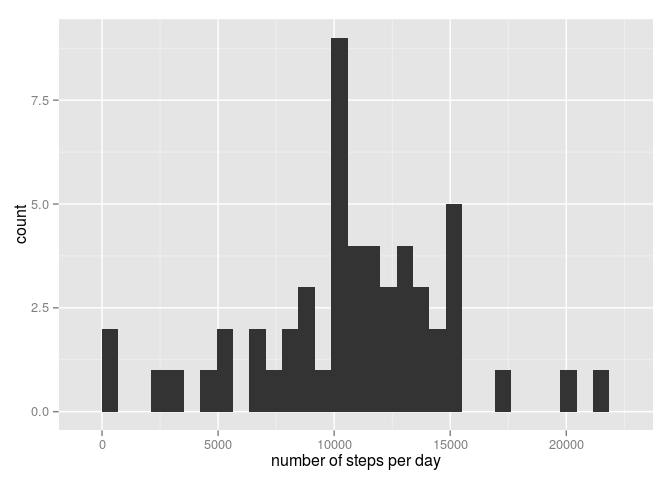

```r
steps_per_day <- aggregate(steps~date, activity_data, sum)
library(ggplot2)
qplot(steps_per_day$steps) + xlab("number of steps per day")
```

2. Calculate and report the mean and median of the total number of steps taken per day

```r
mean(steps_per_day$steps)
```

```
## [1] 10766.19
```

```r
median(steps_per_day$steps)
```

```
## [1] 10765
```

## What is the average daily activity pattern?

1. Make a time series plot of the 5-minute interval (x-axis) and the average number of steps taken, averaged across all days (y-axis)

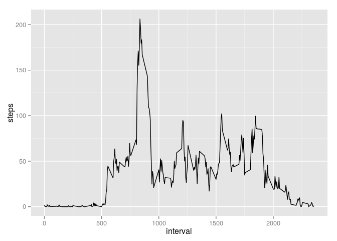

```r
average_daily_activity <- aggregate(steps~interval, activity_data, mean)
ggplot(average_daily_activity, aes(x=interval, y=steps)) + geom_line()
```

2. Which 5-minute interval, on average across all the days in the dataset, contains the maximum number of steps?

```r
average_daily_activity$interval[average_daily_activity$steps == max(average_daily_activity$steps)]
```

```
## [1] 835
```

## Imputing missing values

1. Calculate and report the total number of missing values in the dataset.

```r
sum(is.na(activity_data))
```

```
## [1] 2304
```

2. Devise a strategy for filling in all of the missing values in the dataset. I used the mean for that 5-minute interval.
3. Create a new dataset that is equal to the original dataset but with the missing data filled in.

```r
new_activity_data <- activity_data

f <- function(x){
    if (is.na(x[1])) {
        result <- average_daily_activity[
            average_daily_activity$interval == as.integer(x[3]),2]
    } else {
        result <- x[1]
    }
    as.numeric(result)
}

new_activity_data$steps <- apply(new_activity_data, 1, f)

new_steps_per_day <- aggregate(steps~date, new_activity_data, sum)
```

4. Make a histogram of the total number of steps taken each day

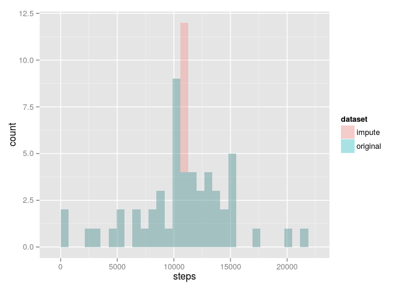

```r
steps_per_day$dataset <- factor("original")
new_steps_per_day$dataset <- factor("impute")

hist_data <- rbind(new_steps_per_day, steps_per_day)

ggplot(hist_data, aes(x=steps, fill=dataset)) + geom_histogram(alpha=0.3, position="identity")
```

and Calculate and report the mean and median total number of steps taken per day.

```r
mean(new_steps_per_day$steps)
```

```
## [1] 10766.19
```

```r
median(new_steps_per_day$steps)
```

```
## [1] 10766.19
```

## Are there differences in activity patterns between weekdays and weekends?

```r
Sys.setlocale("LC_TIME", "C")
```

```
## [1] "C"
```

1. Create a new factor variable in the dataset with two levels – “weekday” and “weekend” indicating whether a given date is a weekday or weekend day.

```r
a <- new_activity_data
a$weekday <- as.factor(weekdays(a$date))
a$type <- as.factor(ifelse(a$weekday == "Saturday" |
                               a$weekday == "Sunday", "weekend", "weekday"))
```

2. Make a panel plot containing a time series plot of the 5-minute interval (x-axis) and the average number of steps taken, averaged across all weekday days or weekend days (y-axis).

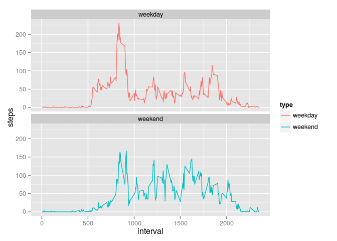

```r
b <- aggregate(steps~interval+type, a, mean)
ggplot(b, aes(x=interval, y=steps, group=type, colour=type)) + geom_line() + facet_wrap(~type, nrow=2)
```